# Ds202_Lab4:Tidying and Joining

SIjie Huang, Hanying Shen

October 24, 2019

## Background

An excerpt of the individual player data of the Cyclone football team is available from Canvas. Dowload the excel file and put the file next to your Rmd files.

Some abbreviations for the column names can be found in the Glossaries sheet in the Excel file.

**References:**

- [Iowa State University Athelete](https://cyclones.com/index.aspx)
- [A Beginner’s Guide to American Football](https://www.youtube.com/watch?v=3t6hM5tRlfA) for the rules of American football.

## Loading Data: Cyclone Football

```r
library(dplyr)
library(tidyr)
```

```r
library(ggplot2)
library(readr)
library(readxl)
library(tidyverse)
defense <-read_excel('cyclonesFootball2018.xlsx', sheet='Defensive')
offense <-read_excel('cyclonesFootball2018.xlsx', sheet='Offensive')
bio <- read_excel('cyclonesFootball2018.xlsx', sheet='Biography')
```

## Part one: Cleaning data

1.The player names and opponent names are factors.

```r
#1
head(defense)
```

```
## # A tibble: 6 x 11
##   Name  Opponent_Oppone~ Tackles_Solo Tackles_ASST Tackles_TFL Tackles_Sack
##   <chr> <chr>            <chr>        <chr>        <chr>       <chr>
## 1 Eisw~ Iowa             3            3            0           0
## 2 Eisw~ Oklahoma         6            8            1.0         0
## 3 Eisw~ Akron            7            2            1.0         0
## 4 Eisw~ TCU              6            3            0           0
## 5 Eisw~ Oklahoma State   3            0            1.0         0
## 6 Eisw~ West Virginia    5            3            1.0         1.0
## # ... with 5 more variables: Turnover_FF <chr>, Turnover_FR <chr>,
## #   Turnover_INT <chr>, Pass_QBH <chr>, Pass_PB <chr>
```

```r
defense$Name<-as.factor(defense$Name)
defense$Opponent_Opponent<-as.factor(defense$Opponent_Opponent)
offense$Name<-as.factor(offense$Name)
offense$Opponent_Opponent<-as.factor(offense$Opponent_Opponent)
bio$Name<-as.factor(bio$Name)
```

2.All offensive and defensive statistics are numerical. The Weight column in Biography is also numeric. (Hint: look at ?mutate_at if you want to save writing some code).

```r
#2
def1<-defense%>%mutate_at(vars(Tackles_Solo
,Tackles_ASST,Tackles_TFL,Tackles_Sack,Turnover_FF,Turnover_FR
,Turnover_INT,Pass_QBH,Pass_PB
),funs(as.numeric))
off1<-offense%>%mutate_at(vars(Receiving_REC, Receiving_YDS, Receiving_TD, Rushing_ATT, Rushing_YDS, Rushing_TD,`Passing_CMP-ATT`, Passing_YDS, Passing_TD, Passing_INT), funs(as.numeric))
bio1<-bio%>%mutate_at(vars(Weight),funs(as.numeric))
```

3.Separate the Height column into two columns. Make sure the newly created columns are numeric. Then create one column that represents Height (Hint: Use a unit that works well). Drop any irrelavant columns from this process.

```r
#3
bio1<-bio%>%separate(Height,c("feet","inch"))
bio1
```

```
## # A tibble: 123 x 8
##    Name      Position   feet  inch  Weight Class     Hometown    Highschool
##    <fct>     <chr>      <chr> <chr> <chr>  <chr>     <chr>       <chr>
##  1 Akers, L~ Wide Rece~ 6     0     192    Redshirt~ Cedar Rapi~ Washington
##  2 Allen, C~ Tight End  6     7     240    Redshirt~ Nixa, Mo.   Nixa
##  3 Alt, Ger~ Offensive~ 6     2     290    Redshirt~ Cedar Rapi~ Washington
##  4 Anderson~ Tight End  6     4     250    Redshirt~ League Cit~ Clear Fal~
##  5 Assalley~ Placekick~ 6     0     191    Redshirt~ Naperville~ Central
##  6 Austin, ~ Linebacker 5     11    205    Redshirt~ Walnut, Ca~ Bishop Am~
##  7 Azunna, ~ Defensive~ 6     0     192    Redshirt~ Grand Prai~ Lake Ridge
##  8 Bailey, ~ Defensive~ 6     3     224    Redshirt~ Clarksdale~ Clarksdale
##  9 Bailey, ~ Defensive~ 6     2     251    Junior    Jacksonvil~ Raines
## 10 Bailey, ~ Defensive~ 6     2     284    Redshirt~ Jacksonvil~ Raines
## # ... with 113 more rows
```

```r
bio1$inch[is.na(bio1$inch)]<-0
bio1$feet<-as.numeric(bio1$feet)
bio1$inch<-as.numeric(bio1$inch)
bio1$feet<-bio1$feet*12
bio1$Height<-bio1$feet+bio1$inch
bio1<-select(bio1,-c(feet,inch))
head(bio1)
```

```
## # A tibble: 6 x 7
##   Name        Position    Weight Class       Hometown     Highschool Height
##   <fct>       <chr>       <chr>  <chr>       <chr>        <chr>       <dbl>
## 1 Akers, Lan~ Wide Recei~ 192    Redshirt S~ Cedar Rapid~ Washington     72
## 2 Allen, Cha~ Tight End   240    Redshirt S~ Nixa, Mo.    Nixa           79
## 3 Alt, Gerry  Offensive ~ 290    Redshirt F~ Cedar Rapid~ Washington     74
## 4 Anderson, ~ Tight End   250    Redshirt S~ League City~ Clear Fal~     76
## 5 Assalley, ~ Placekicker 191    Redshirt S~ Naperville,~ Central        72
## 6 Austin, Aa~ Linebacker  205    Redshirt S~ Walnut, Cal~ Bishop Am~     71
```

4.By cleaning the three data frames in R, at the end of this step you should have the following three clean data frames: defClean, offClean, and bioClean. Print the structures of these data frames. Make sure your data types make sense for each variable.

```r
#4
defClean<-def1
offClean<-off1
bioClean<-bio1
bioClean
```

```
## # A tibble: 123 x 7
##    Name        Position    Weight Class      Hometown     Highschool Height
##    <fct>       <chr>       <chr>  <chr>      <chr>        <chr>       <dbl>
##  1 Akers, Lan~ Wide Recei~ 192    Redshirt ~ Cedar Rapid~ Washington     72
##  2 Allen, Cha~ Tight End   240    Redshirt ~ Nixa, Mo.    Nixa           79
##  3 Alt, Gerry  Offensive ~ 290    Redshirt ~ Cedar Rapid~ Washington     74
##  4 Anderson, ~ Tight End   250    Redshirt ~ League City~ Clear Fal~     76
##  5 Assalley, ~ Placekicker 191    Redshirt ~ Naperville,~ Central        72
##  6 Austin, Aa~ Linebacker  205    Redshirt ~ Walnut, Cal~ Bishop Am~     71
##  7 Azunna, Ar~ Defensive ~ 192    Redshirt ~ Grand Prair~ Lake Ridge     72
##  8 Bailey, Co~ Defensive ~ 224    Redshirt ~ Clarksdale,~ Clarksdale     75
##  9 Bailey, Ja~ Defensive ~ 251    Junior     Jacksonvill~ Raines         74
## 10 Bailey, Jo~ Defensive ~ 284    Redshirt ~ Jacksonvill~ Raines         74
## # ... with 113 more rows
```

```r
str(defClean)
```

```
## Classes 'tbl_df', 'tbl' and 'data.frame':    446 obs. of  11 variables:
##  $ Name             : Factor w/ 42 levels "Akers, Landen",..: 7 7 7 7 7 7 7 7 7 7 ...
##  $ Opponent_Opponent: Factor w/ 13 levels "Akron","Baylor",..: 4 7 1 9 8 13 11 5 2 10 ...
##  $ Tackles_Solo     : num  3 6 7 6 3 5 3 7 2 9 ...
##  $ Tackles_ASST     : num  3 8 2 3 0 3 2 1 4 3 ...
##  $ Tackles_TFL      : num  0 1 1 0 1 1 0 0 0 0 ...
##  $ Tackles_Sack     : num  0 0 0 0 0 1 0 0 0 0 ...
##  $ Turnover_FF      : num  0 1 0 0 0 0 0 0 0 1 ...
##  $ Turnover_FR      : num  0 0 0 0 0 0 0 0 0 0 ...
##  $ Turnover_INT     : num  0 0 0 0 0 0 1 0 0 0 ...
##  $ Pass_QBH         : num  0 0 0 0 0 0 0 0 0 0 ...
##  $ Pass_PB          : num  0 0 3 0 0 0 0 0 0 0 ...
```

```r
str(offClean)
```

```
## Classes 'tbl_df', 'tbl' and 'data.frame':    168 obs. of  12 variables:
##  $ Name             : Factor w/ 15 levels "Akers, Landen",..: 6 6 6 6 6 6 6 6 6 6 ...
##  $ Opponent_Opponent: Factor w/ 13 levels "Akron","Baylor",..: 4 7 1 9 8 13 11 5 2 10 ...
##  $ Receiving_REC    : num  1 9 6 3 6 1 1 4 4 0 ...
##  $ Receiving_YDS    : num  31 66 39 23 37 32 4 31 39 0 ...
##  $ Receiving_TD     : num  0 0 0 0 1 1 0 0 1 0 ...
##  $ Rushing_ATT      : num  NA NA NA NA NA NA NA NA NA NA ...
##  $ Rushing_YDS      : num  NA NA NA NA NA NA NA NA NA NA ...
##  $ Rushing_TD       : num  NA NA NA NA NA NA NA NA NA NA ...
##  $ Passing_CMP-ATT  : num  NA NA NA NA NA NA NA NA NA NA ...
##  $ Passing_YDS      : num  NA NA NA NA NA NA NA NA NA NA ...
##  $ Passing_TD       : num  NA NA NA NA NA NA NA NA NA NA ...
##  $ Passing_INT      : num  NA NA NA NA NA NA NA NA NA NA ...
```

```r
str(bioClean)
```

```
## Classes 'tbl_df', 'tbl' and 'data.frame':    123 obs. of  7 variables:
##  $ Name      : Factor w/ 123 levels "Akers, Landen",..: 1 2 3 4 5 6 7 8 9 10 ...
##  $ Position  : chr  "Wide Receiver" "Tight End" "Offensive Line" "Tight End" ...
##  $ Weight    : chr  "192" "240" "290" "250" ...
##  $ Class     : chr  "Redshirt Sophomore" "Redshirt Sophomore" "Redshirt Freshman" "Redshirt Senior" ...
##  $ Hometown  : chr  "Cedar Rapids, Iowa" "Nixa, Mo." "Cedar Rapids, Iowa" "League City, Texas" ...
##  $ Highschool: chr  "Washington" "Nixa" "Washington" "Clear Falls" ...
##  $ Height    : num  72 79 74 76 72 71 72 75 74 74 ...
```

## Part two: Tidying (A)

For the following questions, work on the cleaned data frames `defClean`, `offClean`, and `bioClean`.

1. Reformat the `defClean` data frame into a tidy format using `gather`. The type of statistic (Tackles_Solo, Tackles_ASST, etc) is added as a **new key column named `Statistic`.**

```r
defClean<-defClean %>% gather(Statistics,key,`Tackles_Solo`:`Pass_PB`)
```

2. Create a histogram for each defensive statistic (make sure to explore different binwidths). Use `facet_wrap` to draw all histograms in a single plot. What defensive skills are rare?

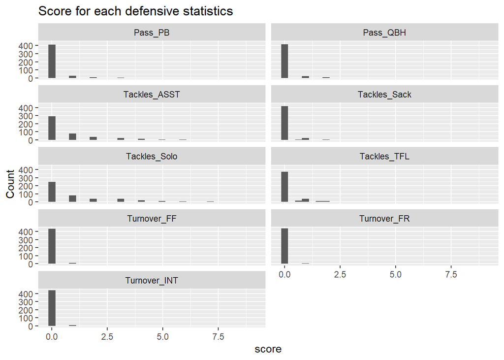

```r
ggplot(data=defClean, aes(key)) + geom_histogram(bins = 30) + facet_wrap(~ Statistics, ncol=2)+labs(title="Score for each defensive statistics",x="score",y="Count")
```

From the histogram, we can see there are only a very small amount of people use Turnover_FF, Turnover_FR and Turnover_INT.So These three defensive skills are rare.

3. Did ISU have better defense against West Virginia or Kansas State? Answer this question by creating a scatterplot with x-axis being the number of solo tackles (by each player) against West Virginia, and y-axis being that against Kansas State. A large number of solo tackles indicates good defense.

   (**Hint**: From step 1 we have gathered our `defClean` into 4 columns.  
   Now we only want to focus on solo tackles (hint…`filter`). Look at your data structure. What form do we need our data to have in order to easily answer this question? (hint…`spread`)).

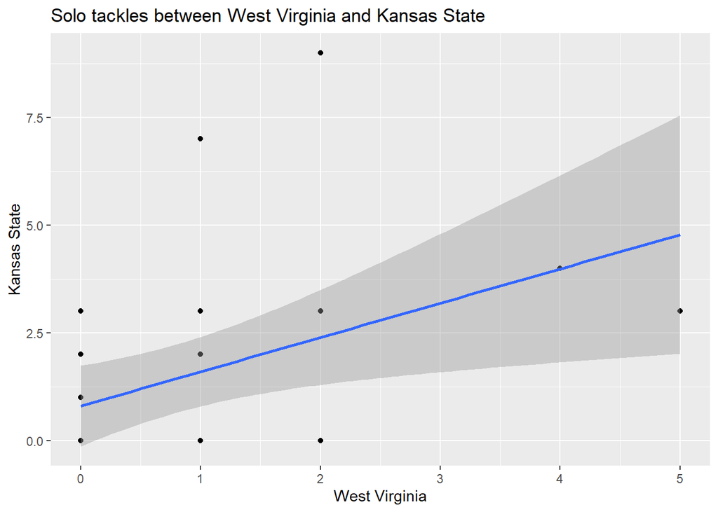

```r
A<-defClean %>% spread(Opponent_Opponent,key) %>% filter(Statistics == "Tackles_Solo") %>% select("Name", "Statistics", "West Virginia","Kansas State")
ggplot(data=A)+geom_point(aes(x=`West Virginia`,y=`Kansas State`))+geom_smooth(aes(x=`West Virginia`,y=`Kansas State`),method='lm')+labs(title="Solo tackles between West Virginia and Kansas State",x="West Virginia",y="Kansas State")
```

From the plot, we can see there is a moderate positive relationship between west virgina and Kansas State,which means Kansas State has larger solo tackles,so ISU have better defense against Kansas State.

## Part two: Tidying (B)

Now let’s turn our attention to the player biography `bioClean`.

1. Separate the `Hometown` column into two columns, namely the city and the state. Print the first few rows of these two columns. (Hint: look at the `sep=` argument of `separate`)

```r
bio2<-bioClean%>%separate(Hometown,c("city","state"),sep=",")
bio2%>% has_name("inch")
```

```
## [1] FALSE
```

```r
bio2
```

```
## # A tibble: 123 x 8
##    Name       Position   Weight Class      city    state  Highschool Height
##    <fct>      <chr>      <chr>  <chr>      <chr>   <chr>  <chr>       <dbl>
##  1 Akers, La~ Wide Rece~ 192    Redshirt ~ Cedar ~ " Iow~ Washington     72
##  2 Allen, Ch~ Tight End  240    Redshirt ~ Nixa    " Mo." Nixa           79
##  3 Alt, Gerry Offensive~ 290    Redshirt ~ Cedar ~ " Iow~ Washington     74
##  4 Anderson,~ Tight End  250    Redshirt ~ League~ " Tex~ Clear Fal~     76
##  5 Assalley,~ Placekick~ 191    Redshirt ~ Naperv~ " Ill~ Central        72
##  6 Austin, A~ Linebacker 205    Redshirt ~ Walnut  " Cal~ Bishop Am~     71
##  7 Azunna, A~ Defensive~ 192    Redshirt ~ Grand ~ " Tex~ Lake Ridge     72
##  8 Bailey, C~ Defensive~ 224    Redshirt ~ Clarks~ " Mis~ Clarksdale     75
##  9 Bailey, J~ Defensive~ 251    Junior     Jackso~ " Fla~ Raines         74
## 10 Bailey, J~ Defensive~ 284    Redshirt ~ Jackso~ " Fla~ Raines         74
## # ... with 113 more rows
```

2. How many players are there from each state?

```r
table(bio2$state)
```

```
##
##      Ariz.       Ark.  Australia     Calif.       D.C.       Fla.
##          3          2          2          8          1          8
##        Ga.       Ill.       Iowa       Kan.      Mass.        Md.
##          2          5         44          3          1          1
##      Mich.      Minn.      Miss.        Mo.       Neb.    Nigeria
##          5          2          1          1          1          1
##       Ohio      Okla.        Pa.       S.C.      Texas        Va.
##         10          4          2          2          9          1
##       Wis.
##          4
```

## Part three: Joining data frames

1. Find out where the offensive players are from by joining the offensive data and player biography data appropriately.

```r
df<-inner_join(bio2,offClean,by="Name")
df
```

```
## # A tibble: 163 x 19
##    Name  Position Weight Class city  state Highschool Height
##    <chr> <chr>    <chr>  <chr> <chr> <chr> <chr>       <dbl>
##  1 Aker~ Wide Re~ 192    Reds~ Ceda~ " Io~ Washington     72
##  2 Aker~ Wide Re~ 192    Reds~ Ceda~ " Io~ Washington     72
##  3 Aker~ Wide Re~ 192    Reds~ Ceda~ " Io~ Washington     72
##  4 Aker~ Wide Re~ 192    Reds~ Ceda~ " Io~ Washington     72
##  5 Aker~ Wide Re~ 192    Reds~ Ceda~ " Io~ Washington     72
##  6 Aker~ Wide Re~ 192    Reds~ Ceda~ " Io~ Washington     72
##  7 Aker~ Wide Re~ 192    Reds~ Ceda~ " Io~ Washington     72
##  8 Aker~ Wide Re~ 192    Reds~ Ceda~ " Io~ Washington     72
##  9 Aker~ Wide Re~ 192    Reds~ Ceda~ " Io~ Washington     72
## 10 Aker~ Wide Re~ 192    Reds~ Ceda~ " Io~ Washington     72
## # ... with 153 more rows, and 11 more variables: Opponent_Opponent <fct>,
## #   Receiving_REC <dbl>, Receiving_YDS <dbl>, Receiving_TD <dbl>,
## #   Rushing_ATT <dbl>, Rushing_YDS <dbl>, Rushing_TD <dbl>,
## #   `Passing_CMP-ATT` <dbl>, Passing_YDS <dbl>, Passing_TD <dbl>,
## #   Passing_INT <dbl>
```

```r
table(df$state)
```

```
##
##  Ariz.   Ark.   Fla.   Iowa    Md.    Mo.   Ohio  Okla.  Texas    Va.
##     10     12     25     13     13      8     30     13     13     13
##   Wis.
##     13
```

2. Is there a relationship between the weight of a player and the receiving yards (`Receiving_YDS`)?

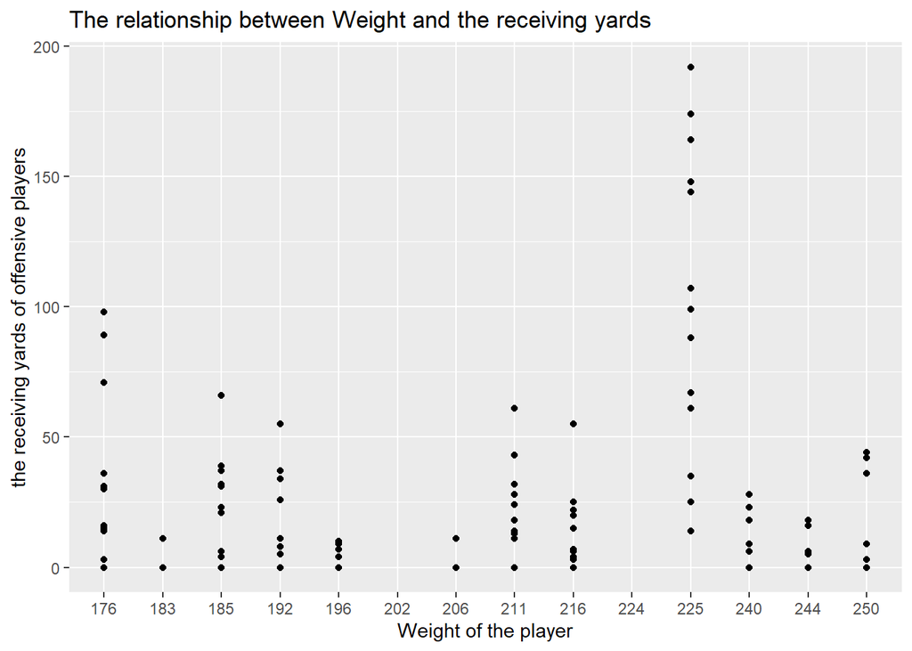

```r
ggplot(data=df,aes(x=Weight,y=Receiving_YDS))+geom_point()+labs(title="The relationship between Weight and the receiving yards", x="Weight of the player",y="the receiving yards of offensive players")
```

From the plot, we can see there are no relationship between Weight and Receiving YDS.

3. Explore more. Raise a question that can be answered only by looking at two or more data frames. Then answer that question.

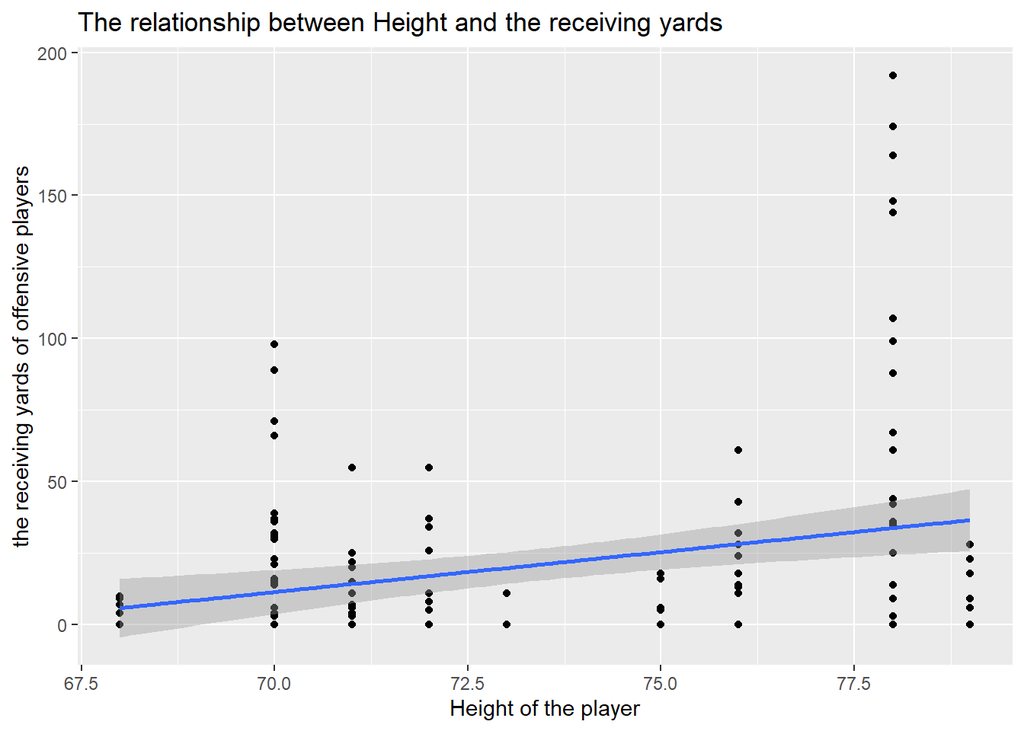

```r
#Is there a relationship between Height of a player and the receiving yards of offensive players?
ggplot(data=df,aes(x=Height,y=Receiving_YDS))+geom_point()+geom_smooth(method='lm')+labs(title="The relationship between Height and the receiving yards", x="Height of the player",y="the receiving yards of offensive players")
```

From the plot, we can see there are weak positive relationship between Height and Receiving YDS of offensive players.